# complete_the_square_E

## complete_the_square_E

#### Question

1. The *not-drawn-to-scale* figure below is composed of a blue square and a red rectangle. Each of the square’s lengths measures $x$ feet. The rectangle is $x$ feet tall and $28$ feet wide.

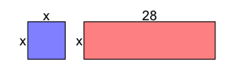

   The total combined area, found by adding together the area of the square and the area of the rectangle, is $429$ square feet.

   What value of $x$ satisfies the conditions stated above?

#### Question

2. The *not-drawn-to-scale* figure below is composed of a blue square and a red rectangle. Each of the square’s lengths measures $x$ feet. The rectangle is $x$ feet tall and $18$ feet wide.

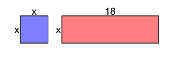

   The total combined area, found by adding together the area of the square and the area of the rectangle, is $208$ square feet.

   What value of $x$ satisfies the conditions stated above?

#### Question

3. The *not-drawn-to-scale* figure below is composed of a blue square and a red rectangle. Each of the square’s lengths measures $x$ feet. The rectangle is $x$ feet tall and $60$ feet wide.

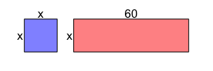

   The total combined area, found by adding together the area of the square and the area of the rectangle, is $1404$ square feet.

   What value of $x$ satisfies the conditions stated above?

#### Question

4. The *not-drawn-to-scale* figure below is composed of a blue square and a red rectangle. Each of the square’s lengths measures $x$ feet. The rectangle is $x$ feet tall and $50$ feet wide.

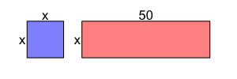

   The total combined area, found by adding together the area of the square and the area of the rectangle, is $1491$ square feet.

   What value of $x$ satisfies the conditions stated above?

#### Question

5. The *not-drawn-to-scale* figure below is composed of a blue square and a red rectangle. Each of the square’s lengths measures $x$ feet. The rectangle is $x$ feet tall and $52$ feet wide.

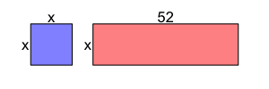

   The total combined area, found by adding together the area of the square and the area of the rectangle, is $480$ square feet.

   What value of $x$ satisfies the conditions stated above?

#### Question

6. The *not-drawn-to-scale* figure below is composed of a blue square and a red rectangle. Each of the square’s lengths measures $x$ feet. The rectangle is $x$ feet tall and $60$ feet wide.

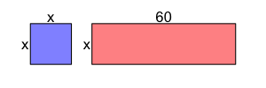

   The total combined area, found by adding together the area of the square and the area of the rectangle, is $2464$ square feet.

   What value of $x$ satisfies the conditions stated above?